# Nature Coast Aquatic Preserve

SEACAR Water Quality Analysis

Last compiled on 15 July, 2026

# Indicators

## Nutrients

### Total Nitrogen - Discrete

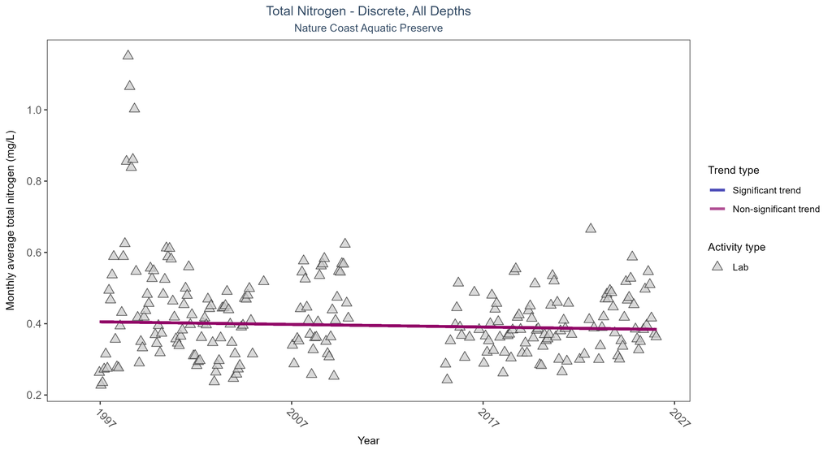

Scatter plot of monthly average total nitrogen over time. If the time series included ten or more years of discrete observations, a significant (blue) or non-significant (magenta) trend line is also shown. Only nitrogen values obtained from laboratory analyses (triangles) are included in the plot.

Table:

Total nitrogen showed no detectable trend between 1996 and 2026.

| Activity Type | Statistical Trend | Sample Count | Years with Data | Period of Record | Median Result Value | Tau | Sen Intercept | Sen Slope | P |
| --- | --- | --- | --- | --- | --- | --- | --- | --- | --- |
| Lab | No detectable trend | 7039 | 25 | 1996 - 2026 | 0.39 | -0.07163 | 0.40605 | -0.00073 | 0.0949 |

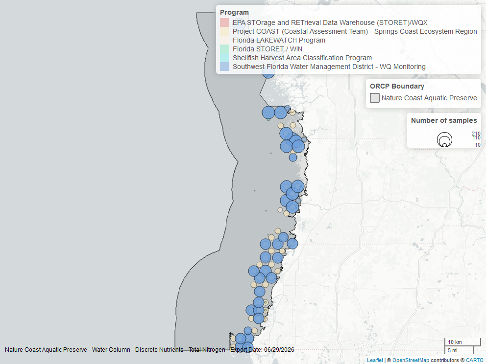

Map showing location of discrete water quality sampling locations within the boundaries of *Nature Coast Aquatic Preserve*. The bubble size on the maps above reflect the amount of data available at each sampling site.

### Total Phosphorus - Discrete

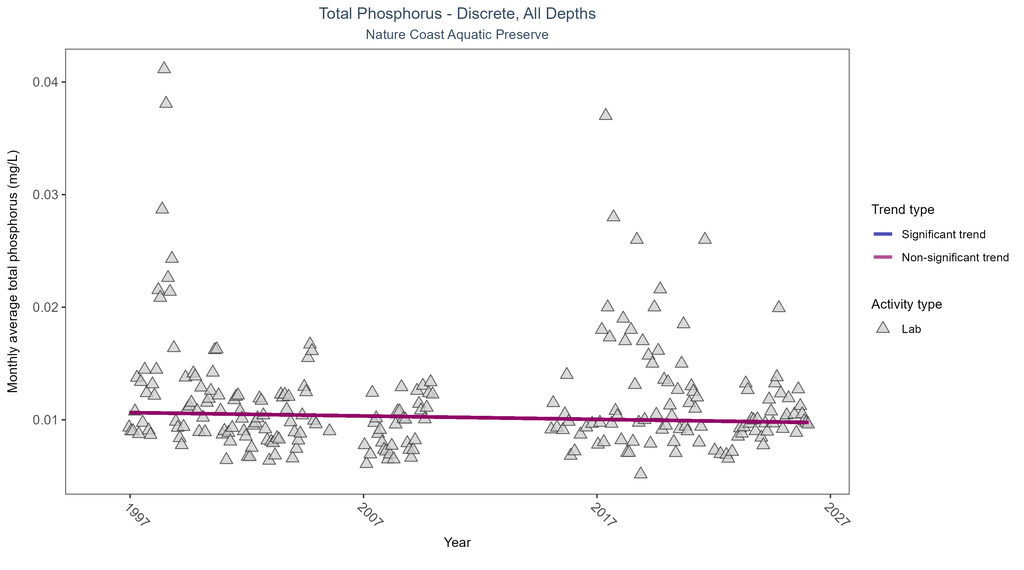

Scatter plot of monthly average total phosphorus over time. If the time series included ten or more years of discrete observations, a significant (blue) or non-significant (magenta) trend line is also shown. Only phosphorus values obtained from laboratory analyses (triangles) are included in the plot.

Table:

Total phosphorus showed no detectable trend between 1996 and 2026.

| Activity Type | Statistical Trend | Sample Count | Years with Data | Period of Record | Median Result Value | Tau | Sen Intercept | Sen Slope | P |
| --- | --- | --- | --- | --- | --- | --- | --- | --- | --- |
| Lab | No detectable trend | 7094 | 25 | 1996 - 2026 | 0.00855 | -0.07942 | 0.01067 | -0.00003 | 0.0701 |

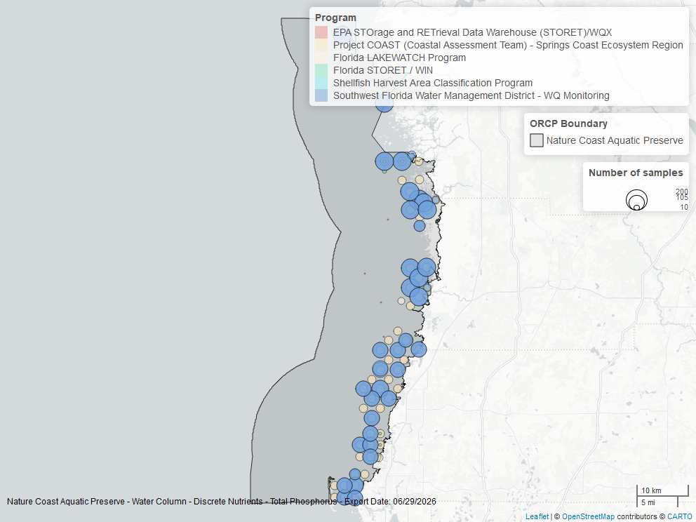

Map showing location of discrete water quality sampling locations within the boundaries of *Nature Coast Aquatic Preserve*. The bubble size on the maps above reflect the amount of data available at each sampling site.

## Water Quality

### Dissolved Oxygen - Continuous

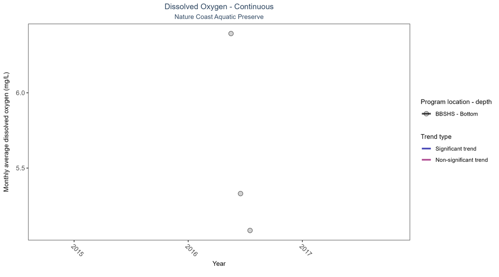

Scatter plot of monthly average dissolved oxygen over time at continuously monitored program locations. Each location is analyzed separately, with significant (blue) or non-significant (magenta) trend lines shown for time series that included five or more years of observations.

Table:

There was insufficient data to fit a model for one location.

| Program Location | Statistical Trend | Sample Count | Years with Data | Period of Record | Median Result Value | Tau | Sen Intercept | Sen Slope | P |
| --- | --- | --- | --- | --- | --- | --- | --- | --- | --- |
| BBSHS | Insufficient data | 6555 | 1 | 2016 - 2016 | 5.7 | - | - | - | - |

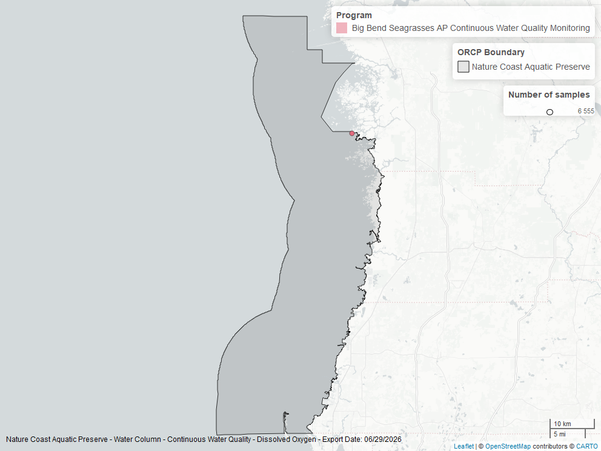

Map showing location of dissolved oxygen continuous water quality sampling locations within the boundaries of *Nature Coast Aquatic Preserve*. The bubble size on the maps above reflect the amount of data available at each sampling site.

### Dissolved Oxygen - Discrete

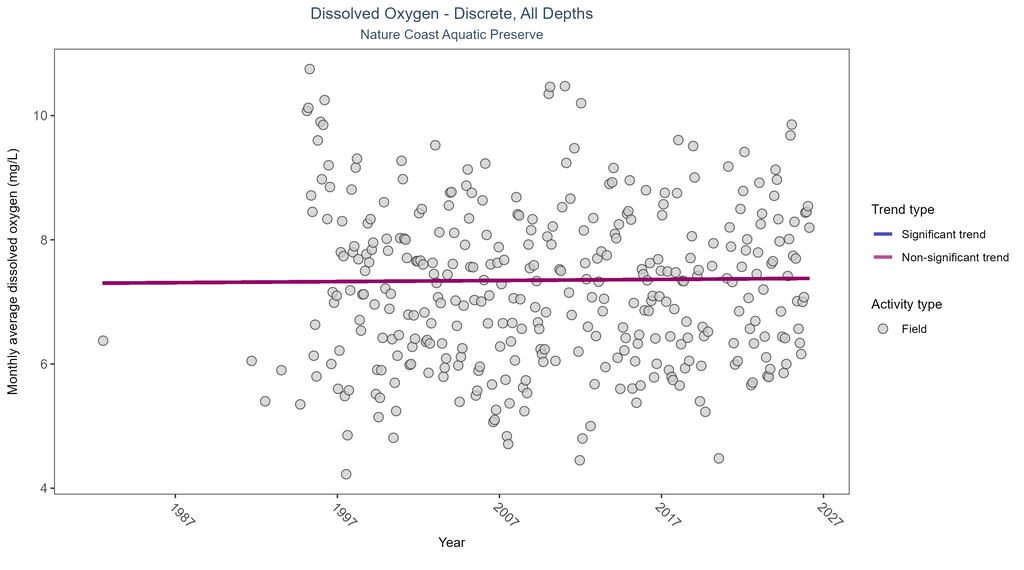

Scatter plot of monthly average dissolved oxygen over time. If the time series included ten or more years of discrete observations, a significant (blue) or non-significant (magenta) trend line is also shown. Only dissolved oxygen values measured in the field (circles) are included in the plot.

Table:

Dissolved oxygen showed no detectable trend between 1982 and 2026.

| Activity Type | Statistical Trend | Sample Count | Years with Data | Period of Record | Median Result Value | Tau | Sen Intercept | Sen Slope | P |
| --- | --- | --- | --- | --- | --- | --- | --- | --- | --- |
| Field | No detectable trend | 10309 | 37 | 1982 - 2026 | 7.21 | 0.01471 | 7.30108 | 0.00175 | 0.6866 |

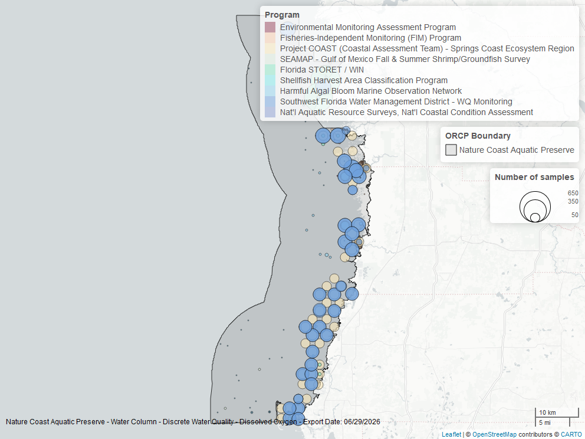

Map showing location of discrete water quality sampling locations within the boundaries of *Nature Coast Aquatic Preserve*. The bubble size on the maps above reflect the amount of data available at each sampling site.

### Dissolved Oxygen Saturation - Continuous

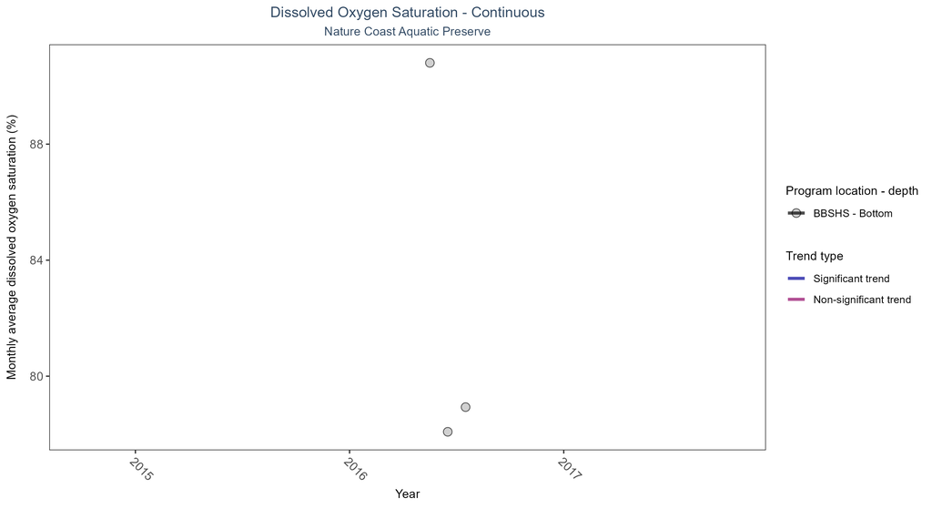

Scatter plot of monthly average dissolved oxygen saturation over time at continuously monitored program locations. Each location is analyzed separately, with significant (blue) or non-significant (magenta) trend lines shown for time series that included five or more years of observations.

Table:

There was insufficient data to fit a model for one location.

| Program Location | Statistical Trend | Sample Count | Years with Data | Period of Record | Median Result Value | Tau | Sen Intercept | Sen Slope | P |
| --- | --- | --- | --- | --- | --- | --- | --- | --- | --- |
| BBSHS | Insufficient data | 6555 | 1 | 2016 - 2016 | 82.6 | - | - | - | - |

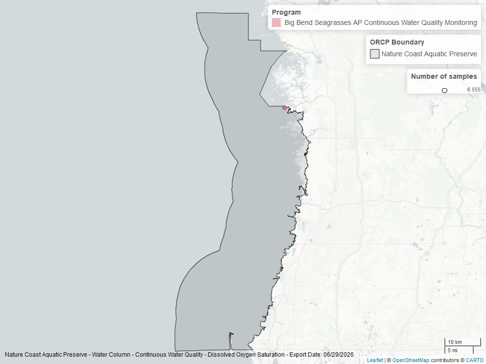

Map showing location of dissolved oxygen saturation continuous water quality sampling locations within the boundaries of *Nature Coast Aquatic Preserve*. The bubble size on the maps above reflect the amount of data available at each sampling site.

### Dissolved Oxygen Saturation - Discrete

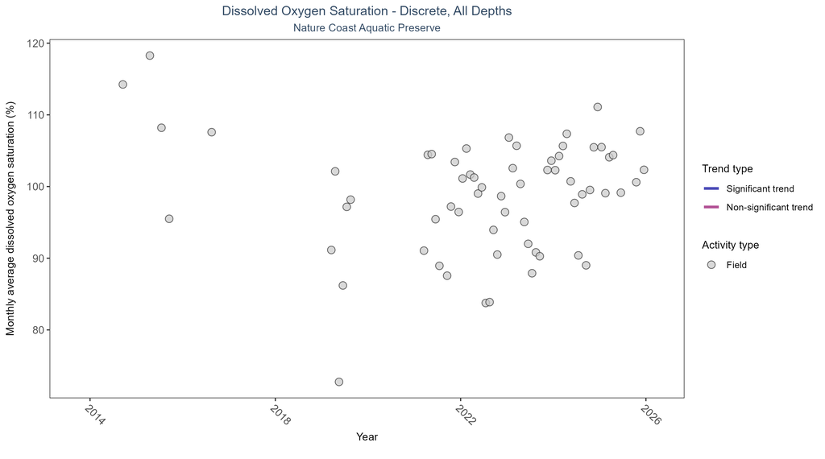

Scatter plot of monthly average dissolved oxygen saturation over time. If the time series included ten or more years of discrete observations, a significant (blue) or non-significant (magenta) trend line is also shown. Only dissolved oxygen saturation values measured in the field (circles) are included in the plot.

Table:

There was insufficient data to fit a model for dissolved oxygen saturation.

| Activity Type | Statistical Trend | Sample Count | Years with Data | Period of Record | Median Result Value | Tau | Sen Intercept | Sen Slope | P |
| --- | --- | --- | --- | --- | --- | --- | --- | --- | --- |
| Field | Insufficient data | 3260 | 9 | 2014 - 2025 | 100.4 | - | - | - | - |

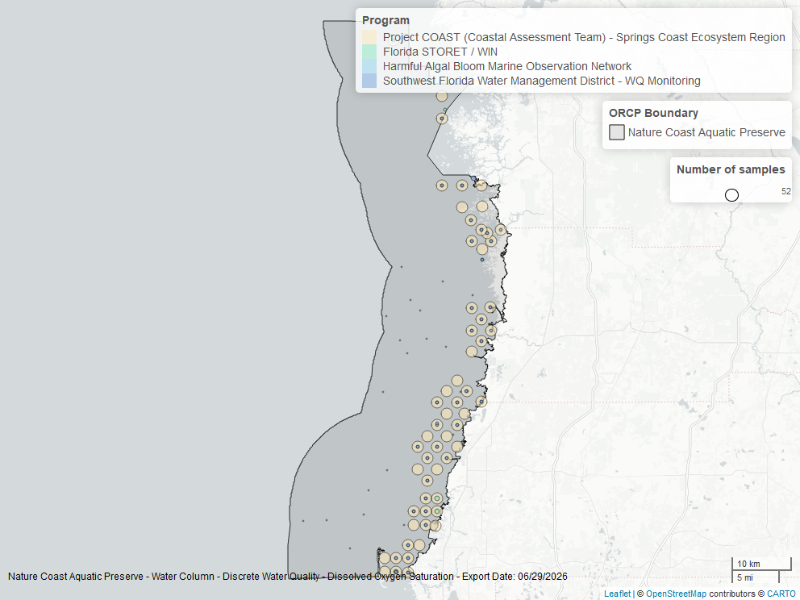

Map showing location of discrete water quality sampling locations within the boundaries of *Nature Coast Aquatic Preserve*. The bubble size on the maps above reflect the amount of data available at each sampling site.

### Salinity - Discrete

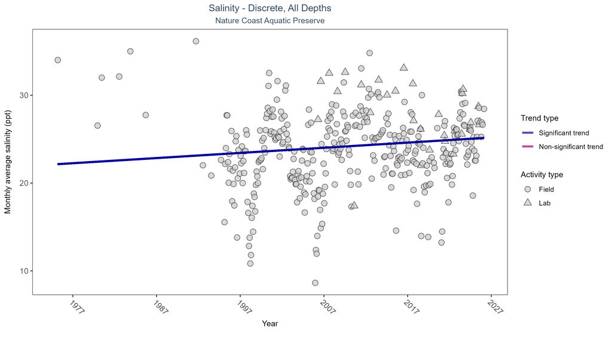

Scatter plot of monthly average salinity over time. If the time series included ten or more years of discrete observations, significant (blue) or non-significant (magenta) trend lines are also shown. Discrete salinity values derived from grab samples analyzed in the field (circles) or the laboratory (triangles) are both included in the plot.

Table:

Monthly average salinity increased by 0.06 ppt per year.

| Activity Type | Statistical Trend | Sample Count | Years with Data | Period of Record | Median Result Value | Tau | Sen Intercept | Sen Slope | P |
| --- | --- | --- | --- | --- | --- | --- | --- | --- | --- |
| All | Increasing trend | 11210 | 42 | 1975 - 2026 | 24.62 | 0.09253 | 22.14096 | 0.05862 | 0.0123 |

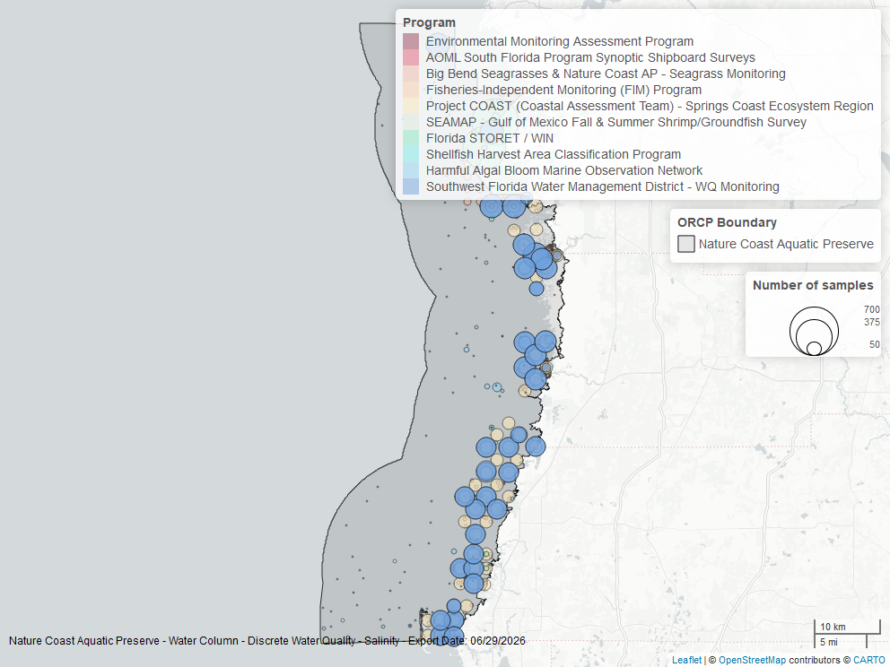

Map showing location of discrete water quality sampling locations within the boundaries of *Nature Coast Aquatic Preserve*. The bubble size on the maps above reflect the amount of data available at each sampling site.

### Salinity - Continuous

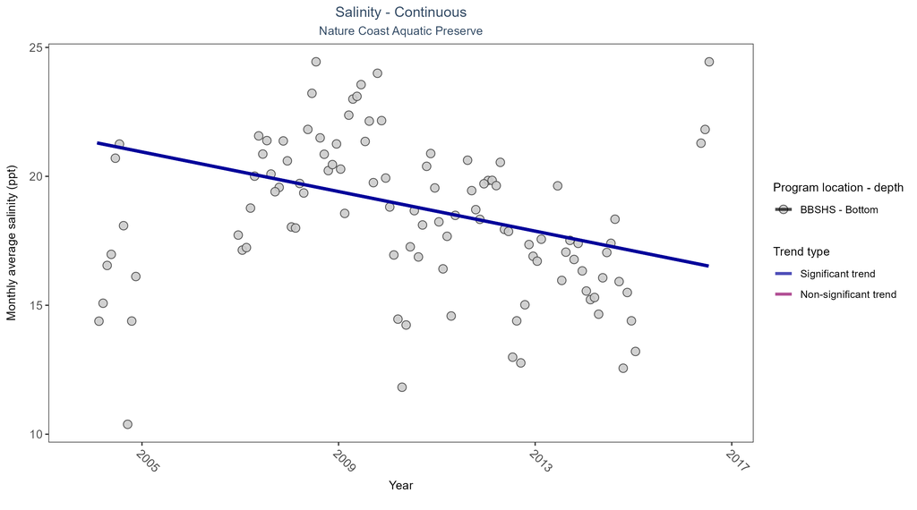

Scatter plot of monthly average salinity over time at continuously monitored program locations. Each location is analyzed separately, with significant (blue) or non-significant (magenta) trend lines shown for time series that included five or more years of observations.

Table:

At one program location, monthly average salinity decreased by 0.38 ppt per year.

| Program Location | Statistical Trend | Sample Count | Years with Data | Period of Record | Median Result Value | Tau | Sen Intercept | Sen Slope | P |
| --- | --- | --- | --- | --- | --- | --- | --- | --- | --- |
| BBSHS | Decreasing trend | 235670 | 12 | 2004 - 2016 | 18.4 | -0.22 | 21.33 | -0.38 | 0 |

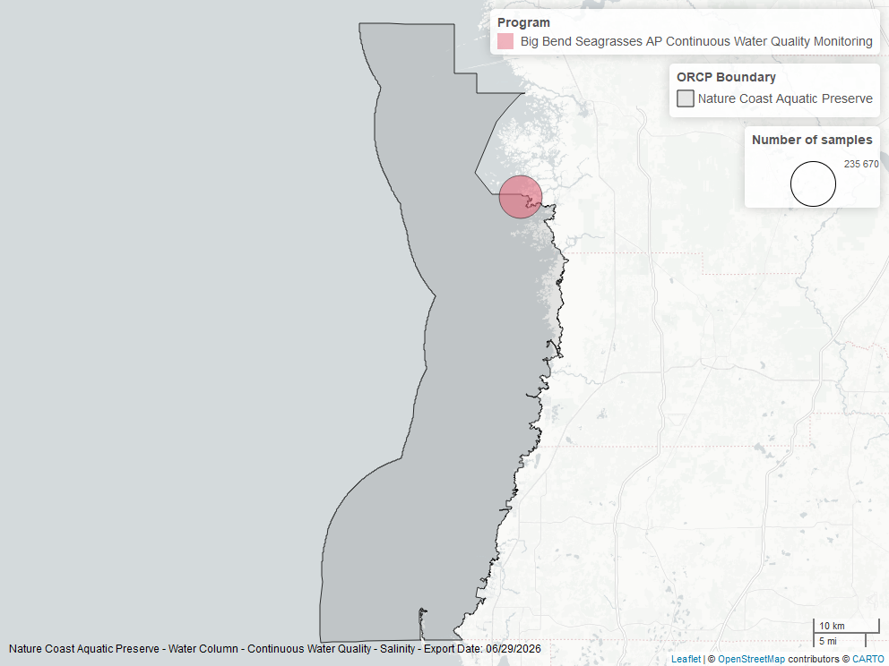

Map showing location of salinity continuous water quality sampling locations within the boundaries of *Nature Coast Aquatic Preserve*. The bubble size on the maps above reflect the amount of data available at each sampling site.

### Water Temperature - Continuous

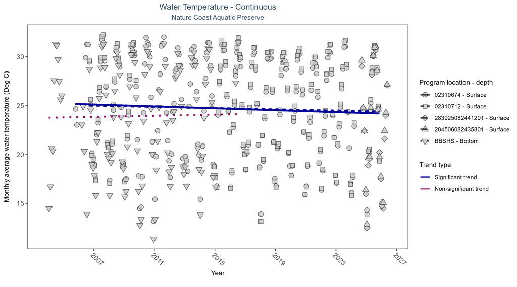

Scatter plot of monthly average water temperature over time at continuously monitored program locations. Each location is analyzed separately, with significant (blue) or non-significant (magenta) trend lines shown for time series that included five or more years of observations.

Table:

At two program locations, monthly average water temperature decreased by 0.03°C per year at one site and by 0.05°C per year at the other. No detectable change in monthly average water temperature was observed at one location. There was insufficient data to fit a model for two locations.

| Program Location | Statistical Trend | Sample Count | Years with Data | Period of Record | Median Result Value | Tau | Sen Intercept | Sen Slope | P |
| --- | --- | --- | --- | --- | --- | --- | --- | --- | --- |
| 02310674 | Decreasing trend | 9951 | 21 | 2005 - 2025 | 25.5 | -0.17 | 25.22 | -0.05 | 0 |
| 02310712 | Decreasing trend | 7075 | 16 | 2006 - 2025 | 25.4 | -0.12 | 25.03 | -0.03 | 0.04 |
| 283925082441201 | Insufficient data | 931 | 3 | 2024 - 2026 | 22.5 | - | - | - | - |
| 284506082435801 | Insufficient data | 1033 | 3 | 2024 - 2026 | 22.7 | - | - | - | - |
| BBSHS | No detectable trend | 244110 | 12 | 2004 - 2016 | 24.5 | 0.05 | 23.77 | 0.03 | 0.52 |

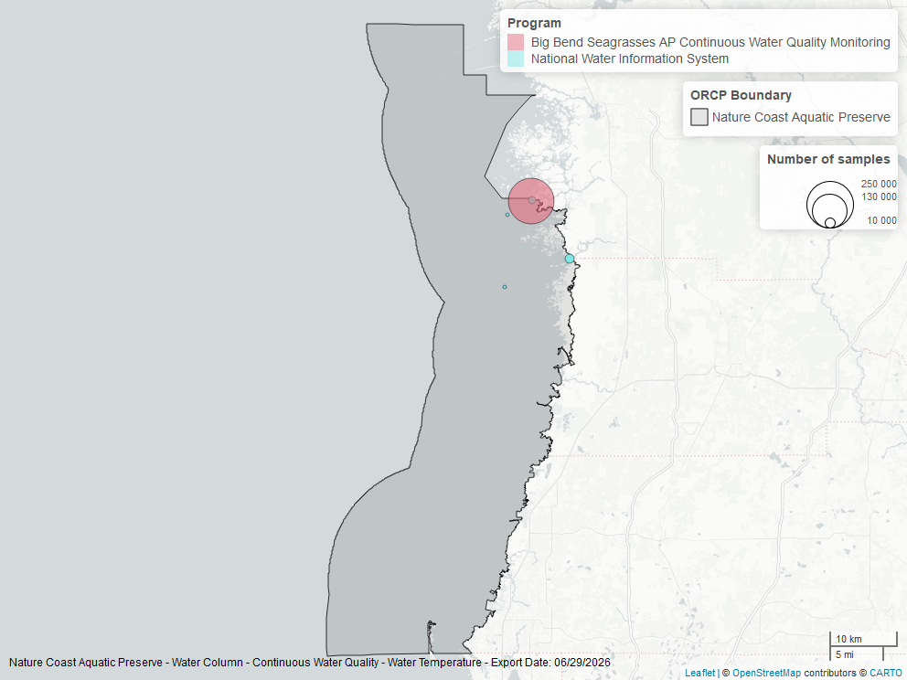

Map showing location of water temperature continuous water quality sampling locations within the boundaries of *Nature Coast Aquatic Preserve*. The bubble size on the maps above reflect the amount of data available at each sampling site.

### Water Temperature - Discrete

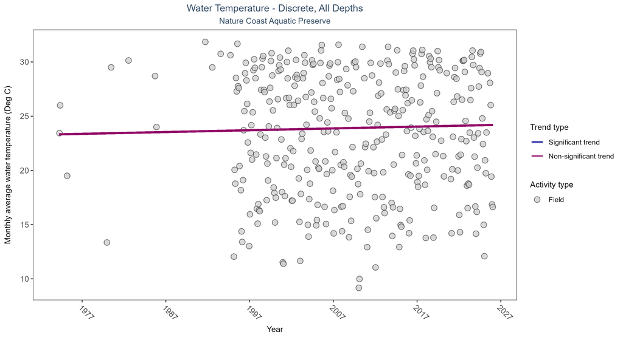

Scatter plot of monthly average water temperature over time. If the time series included ten or more years of discrete observations, a significant (blue) or non-significant (magenta) trend line is also shown. Only water temperature measurements taken in the field (circles) are included in the plot.

Table:

Water temperature showed no detectable trend between 1974 and 2026.

| Activity Type | Statistical Trend | Sample Count | Years with Data | Period of Record | Median Result Value | Tau | Sen Intercept | Sen Slope | P |
| --- | --- | --- | --- | --- | --- | --- | --- | --- | --- |
| Field | No detectable trend | 9150 | 42 | 1974 - 2026 | 24.1 | 0.07196 | 23.32112 | 0.01667 | 0.0611 |

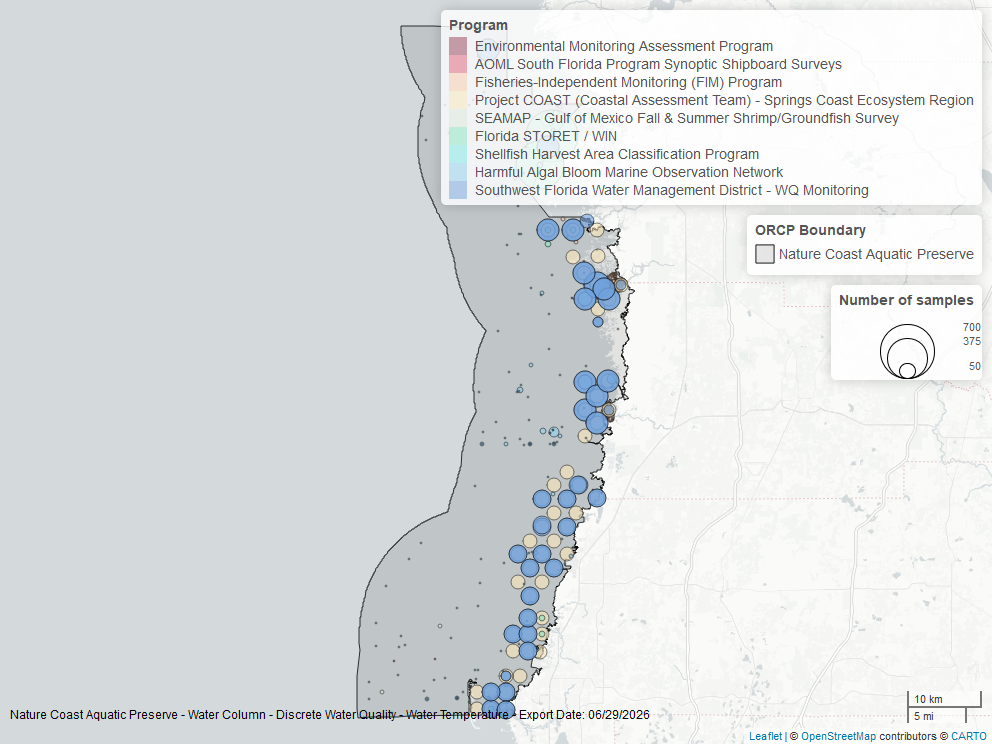

Map showing location of discrete water quality sampling locations within the boundaries of *Nature Coast Aquatic Preserve*. The bubble size on the maps above reflect the amount of data available at each sampling site.

### pH - Continuous

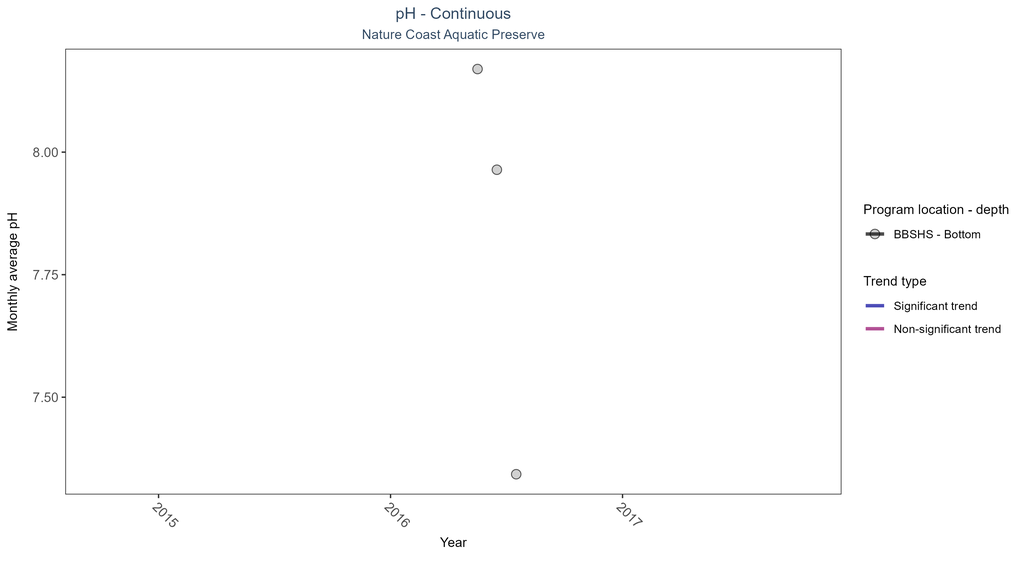

Scatter plot of monthly average pH over time at continuously monitored program locations. Each location is analyzed separately, with significant (blue) or non-significant (magenta) trend lines shown for time series that included five or more years of observations.

Table:

There was insufficient data to fit a model for one location.

| Program Location | Statistical Trend | Sample Count | Years with Data | Period of Record | Median Result Value | Tau | Sen Intercept | Sen Slope | P |
| --- | --- | --- | --- | --- | --- | --- | --- | --- | --- |
| BBSHS | Insufficient data | 6555 | 1 | 2016 - 2016 | 8 | - | - | - | - |

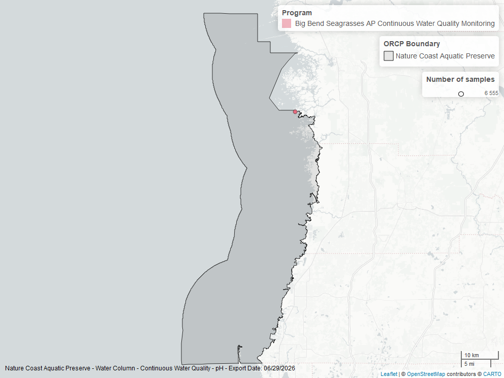

Map showing location of ph continuous water quality sampling locations within the boundaries of *Nature Coast Aquatic Preserve*. The bubble size on the maps above reflect the amount of data available at each sampling site.

### pH - Discrete

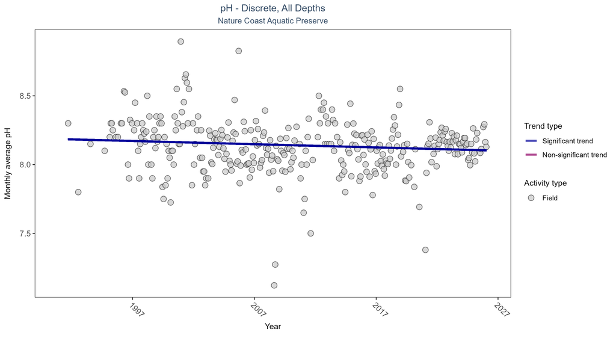

Scatter plot of monthly average pH over time. If the time series included ten or more years of discrete observations, a significant (blue) or non-significant (magenta) trend line is also shown. Only pH values measured in the field (circles) are included in the plot.

Table:

Monthly average pH decreased by less than 0.01 pH units per year.

| Activity Type | Statistical Trend | Sample Count | Years with Data | Period of Record | Median Result Value | Tau | Sen Intercept | Sen Slope | P |
| --- | --- | --- | --- | --- | --- | --- | --- | --- | --- |
| Field | Decreasing trend | 7985 | 36 | 1991 - 2026 | 8.15 | -0.08656 | 8.18571 | -0.00234 | 0.0232 |

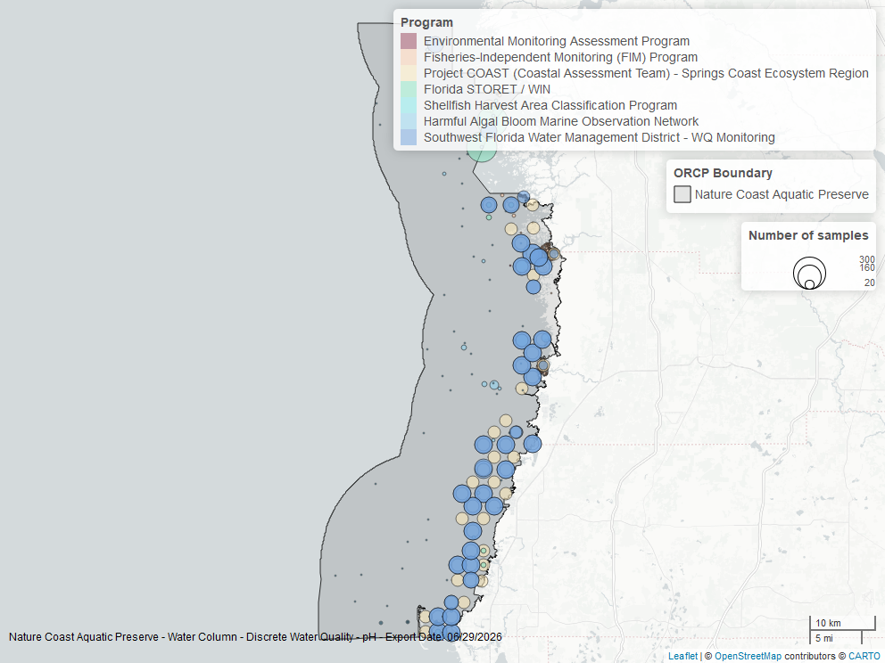

Map showing location of discrete water quality sampling locations within the boundaries of *Nature Coast Aquatic Preserve*. The bubble size on the maps above reflect the amount of data available at each sampling site.

### Specific Conductivity - Continuous

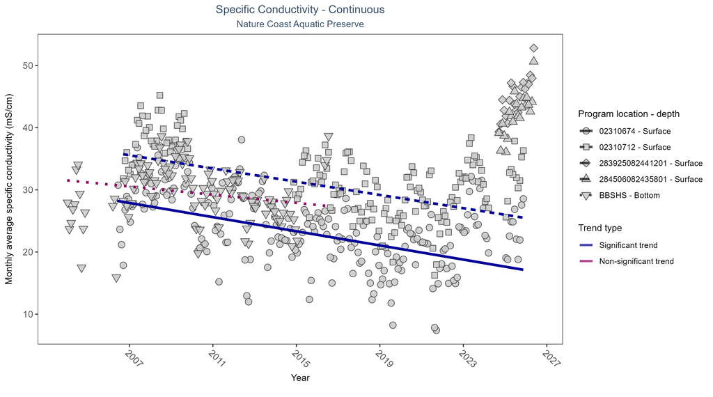

Scatter plot of monthly average specific conductivity over time at continuously monitored program locations. Each location is analyzed separately, with significant (blue) or non-significant (magenta) trend lines shown for time series that included five or more years of observations.

Table:

At two program locations, monthly average specific conductivity decreased by 0.53 mS/cm per year at one site and by 0.57 mS/cm per year at the other. No detectable change in monthly average specific conductivity was observed at one location. There was insufficient data to fit a model for two locations.

| Program Location | Statistical Trend | Sample Count | Years with Data | Period of Record | Median Result Value | Tau | Sen Intercept | Sen Slope | P |
| --- | --- | --- | --- | --- | --- | --- | --- | --- | --- |
| 02310674 | Decreasing trend | 12487 | 20 | 2006 - 2025 | 23.80 | -0.37 | 28.46 | -0.57 | 0 |
| 02310712 | Decreasing trend | 10064 | 16 | 2006 - 2025 | 32.60 | -0.38 | 36.1 | -0.53 | 0 |
| 283925082441201 | Insufficient data | 1643 | 3 | 2024 - 2026 | 45.30 | - | - | - | - |
| 284506082435801 | Insufficient data | 1642 | 3 | 2024 - 2026 | 42.60 | - | - | - | - |
| BBSHS | No detectable trend | 244109 | 12 | 2004 - 2016 | 29.73 | -0.13 | 31.53 | -0.33 | 0.07 |

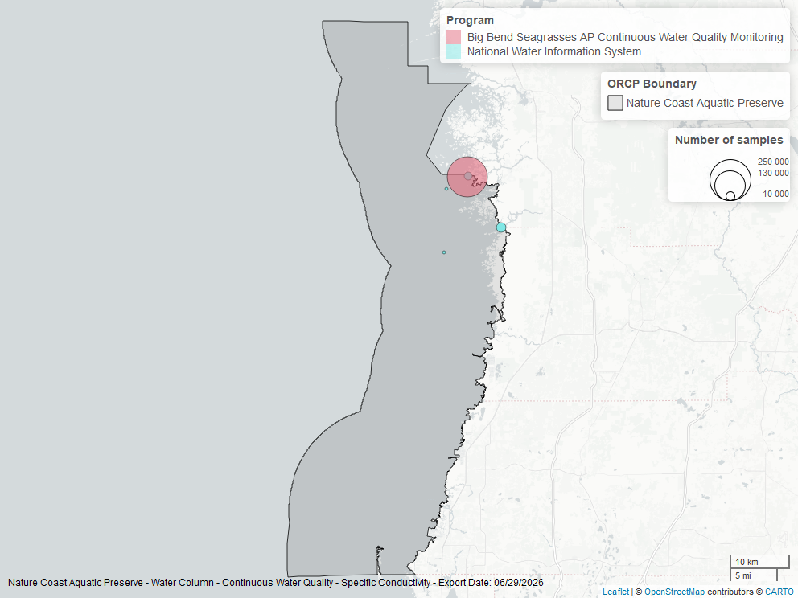

Map showing location of specific conductivity continuous water quality sampling locations within the boundaries of *Nature Coast Aquatic Preserve*. The bubble size on the maps above reflect the amount of data available at each sampling site.

## Water Clarity

### Turbidity - Continuous

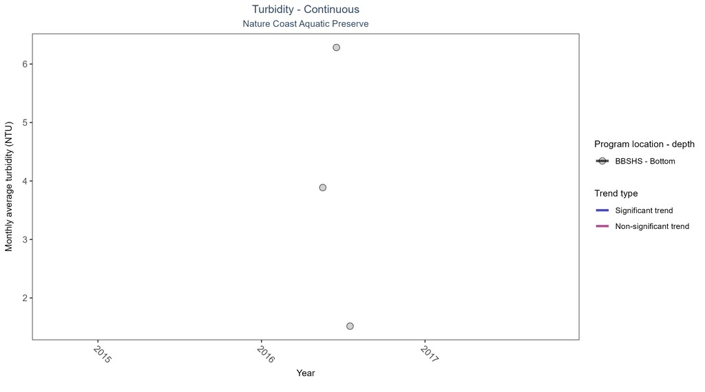

Scatter plot of monthly average turbidity over time at continuously monitored program locations. Each location is analyzed separately, with significant (blue) or non-significant (magenta) trend lines shown for time series that included five or more years of observations.

Table:

There was insufficient data to fit a model for one location.

| Program Location | Statistical Trend | Sample Count | Years with Data | Period of Record | Median Result Value | Tau | Sen Intercept | Sen Slope | P |
| --- | --- | --- | --- | --- | --- | --- | --- | --- | --- |
| BBSHS | Insufficient data | 6368 | 1 | 2016 - 2016 | 2 | - | - | - | - |

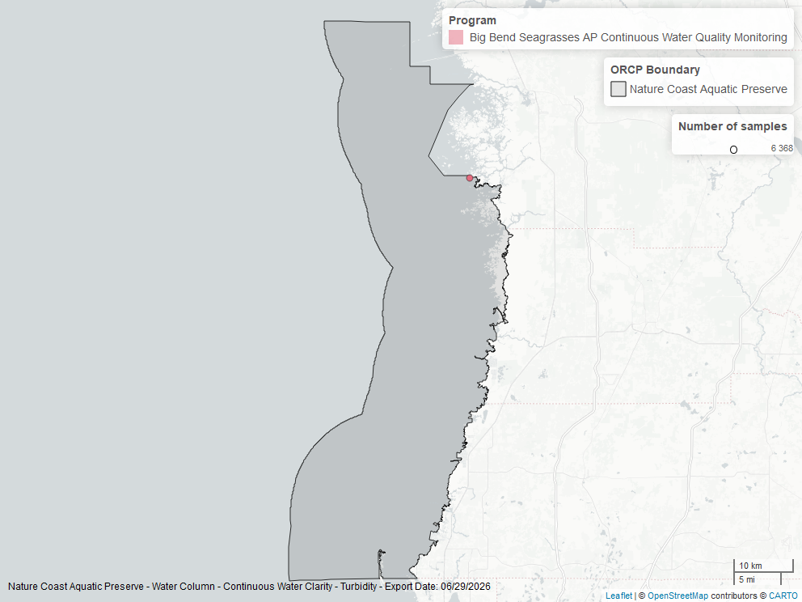

Map showing location of turbidity continuous water quality sampling locations within the boundaries of *Nature Coast Aquatic Preserve*. The bubble size on the maps above reflect the amount of data available at each sampling site.

### Turbidity - Discrete

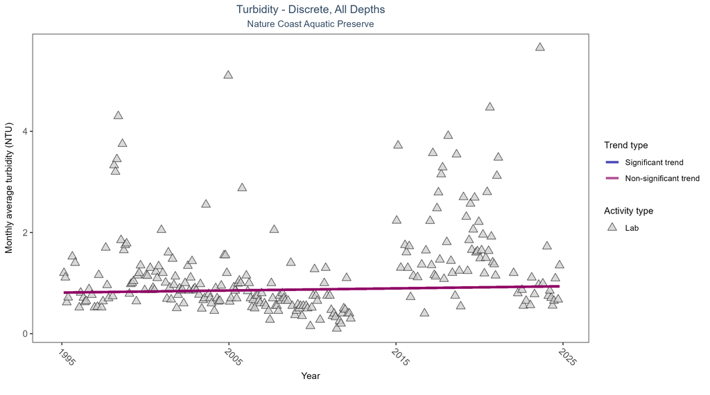

Scatter plot of monthly average turbidity over time. If the time series included ten or more years of discrete observations, a significant (blue) or non-significant (magenta) trend line is also shown. Only turbidity values measured in the laboratory (triangles) are included in the plot.

Table:

Turbidity showed no detectable trend between 1995 and 2024.

| Activity Type | Statistical Trend | Sample Count | Years with Data | Period of Record | Median Result Value | Tau | Sen Intercept | Sen Slope | P |
| --- | --- | --- | --- | --- | --- | --- | --- | --- | --- |
| Lab | No detectable trend | 1823 | 28 | 1995 - 2024 | 0.87 | 0.04785 | 0.81251 | 0.00415 | 0.2291 |

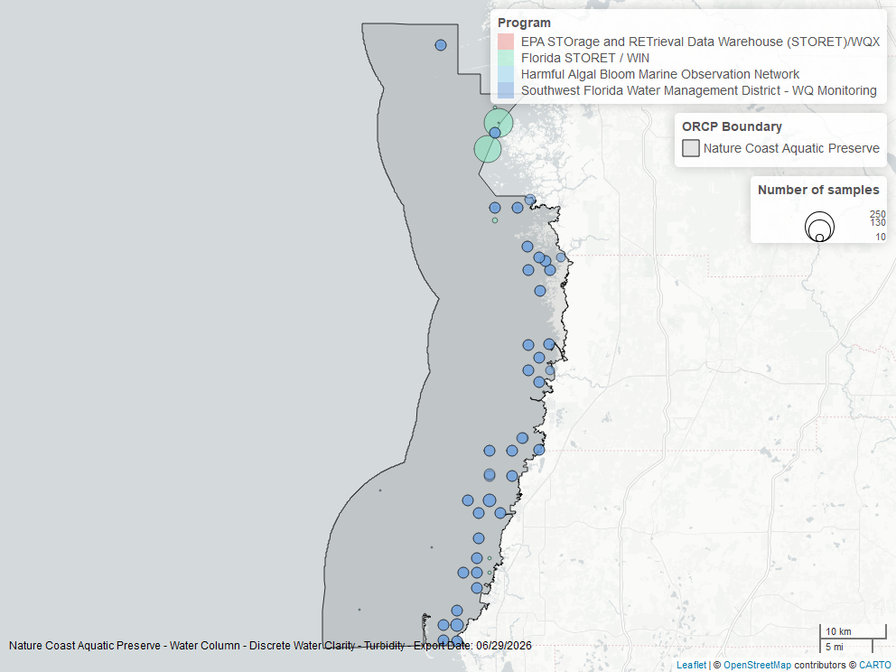

Map showing location of discrete water quality sampling locations within the boundaries of *Nature Coast Aquatic Preserve*. The bubble size on the maps above reflect the amount of data available at each sampling site.

### Total Suspended Solids - Discrete

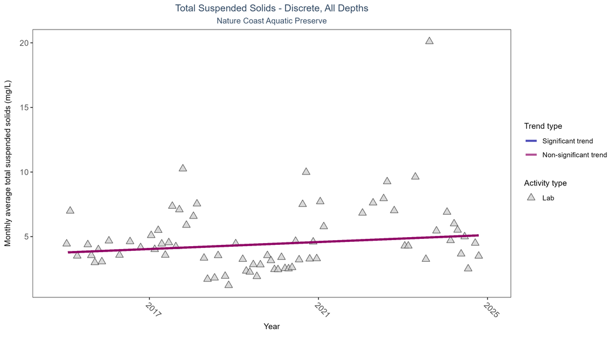

Scatter plot of monthly average total suspended solids (TSS) over time. If the time series included ten or more years of discrete observations, a significant (blue) or non-significant (magenta) trend line is also shown. Only TSS values obtained from laboratory analyses (triangles) are included in the plot.

Table:

Total suspended solids showed no detectable trend between 2015 and 2024.

| Activity Type | Statistical Trend | Sample Count | Years with Data | Period of Record | Median Result Value | Tau | Sen Intercept | Sen Slope | P |
| --- | --- | --- | --- | --- | --- | --- | --- | --- | --- |
| Lab | No detectable trend | 1302 | 10 | 2015 - 2024 | 3.425 | 0.20815 | 3.771 | 0.13539 | 0.1146 |

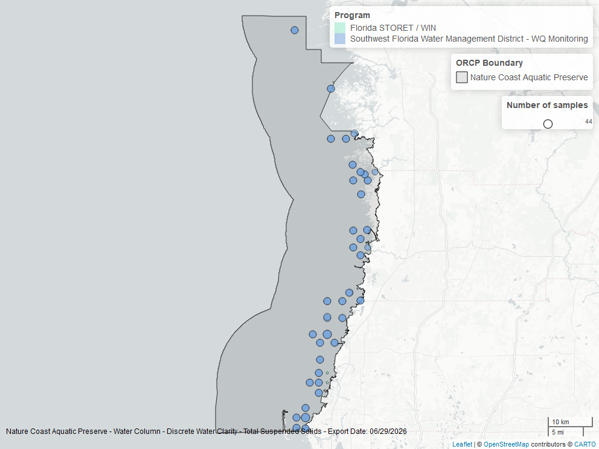

Map showing location of discrete water quality sampling locations within the boundaries of *Nature Coast Aquatic Preserve*. The bubble size on the maps above reflect the amount of data available at each sampling site.